# Homework1-JayceH-Final

### CSCI 477/577: Homework 1

Due 02/24/2023

#### Problem 1: Comparing the motion of two objects (Gould 3.11)

Consider the motion of two identical objects that both start from a height h. One object is dropped vertically from rest and the other is thrown with a horizontal velocity v0,x. Which object reaches the ground first?

1. Give reasons for your answer assuming that air resistance can be neglected.

Given that both objects have only horizontal velocities and gravity affecting them the objects with reach the ground at the same time.

Here is a plot showcasing this phenomenon:

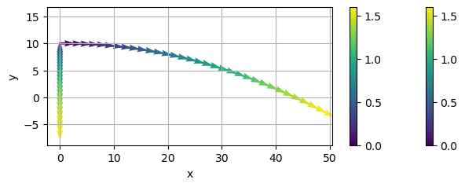

2. Assume that air resistance cannot be neglected and that the drag force is proportional to |v|^2. Give reasons for your anticipated answer for this case. Then perform numerical simulations using, for example, c_d/m = 0.1, h = 10m, and v_0,x = 30 m/s. Are your qualitative results consistent with your anticipated answer?

Since air resistance is a new force in this system that works against gravity and velocity, it will take more for that object to object to reach height of 0.

Here is a plot of this simulation:

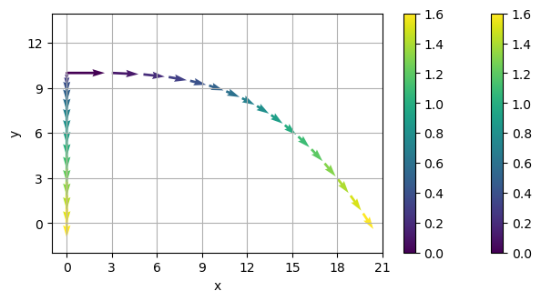

This is showing that it takes more time to reach height of 0 compared to the plot above with this new addition of air resistance.

3. Suppose that the drag force is proportional to |v| rather than to |v|^2. Is your anticipated answer similar to that in part (b)? Do a numerical simulation to test your intuition.

With the drag force proportional to |v| instead of |v|^2, the results should be similar in the time it takes to reach height 0 but the distance will vary.

With the |v| the distance is much longer to reach height 0 as shown below:

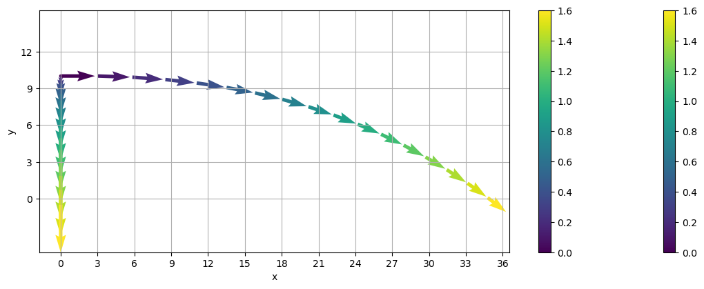

#### Problem 2: Conservation of energy

Consider the problem of a simple harmonic oscillator, which obeys the equation

$$ \begin{equation} \frac{dv}{dt} = -x \end{equation} $$$$ \begin{equation} \frac{dx}{dt} = v \end{equation} $$

with initial conditions $x_{0}$ = 1 and $v_{0}$ = 0. The total energy of this system is given by

$$ \begin{equation} E = \frac{1}{2}v^2 + \frac{1}{2}x^2 \end{equation} $$

with a true value of $E = \frac{1}{2}$.

1. Show that the energy error for the Euler-Cromer scheme is proportional to $\Delta t^2$ by making a log-log plot of the energy error $|E_{1} −\frac{1}{2}|$ versus $\Delta t$ and evaluating the slope of the resulting line.

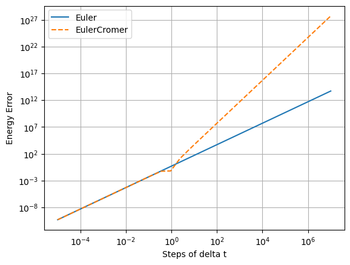

2. Do the same analysis but for the average error over a single period of the oscillator, which for this problem is $T = 2π$ (i.e. integrate the equations from $t = 0$ to $t = T$ and compute the same energy error metric as before, but averaged over all time steps). Show that the error for Euler grows proportionally to $\Delta t$, but that the error for Euler-Cromer still grows as $\Delta t^2$.

Plot with a larger delta t range

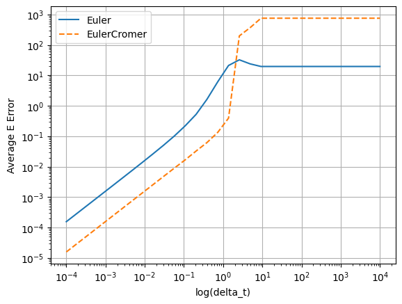

Plot for a delta t range between 10^-1 and 10^1

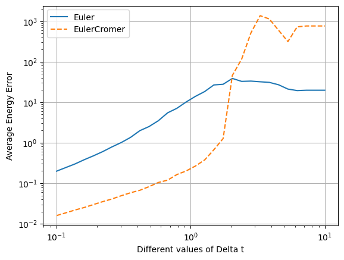

#### Problem 3: The coffee cup (Gould 3.14)

The nature of the energy transfer from the hot water in a cup of coffee to the surrounding air is complicated and, in general, involves the mechanisms of convection, radiation, evaporation, and conduction. However, if the temperature difference between the water and its surroundings is not too large, the rate of change of the temperature of the water may be assumed to be proportional to the temperature difference. We can formulate this statement more precisely in terms of a differential equation: $$ \begin{equation} \frac{dT}{dt} = -r(T-T_{s}) \end{equation} $$ where $T$ is the temperature of the water, $T_{s}$ is the temperature of its surroundings, and $r$ is the cooling constant. The minus sign in (3.21) implies that if $T$ > $T_{s}$, the temperature of the water will decrease with time. The value of the cooling constant r depends on the heat transfer mechanism, the contact area with the surroundings, and the thermal properties of the water. The relation is sometimes known as Newton’s law of cooling, even though the relation is only approximate, and Newton did not express the rate of cooling in this form.

1. Write a program that computes the numerical solution. Test your program by choosing the initial temperature $T_{0} = 100C, T_{s} = 0C$, and $r = 1$.

Test plot of the coffee cup program:

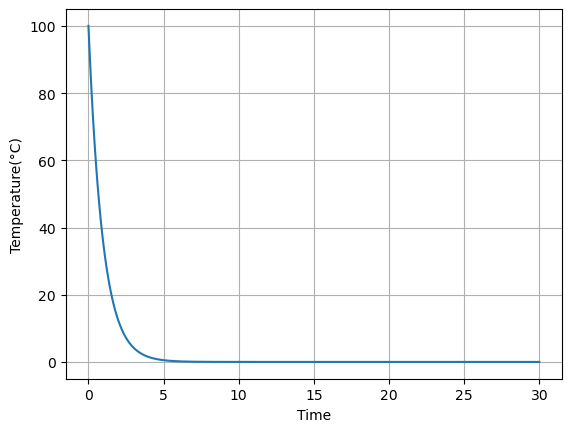

2. Model the cooling of a cup of coffee by choosing $r = 0.03$. What are the units of r? Plot the temperature $T$ as a function of the time using $T_{0} = 87C$ and $T_{s} = 17C$. Make sure that your value of $\Delta t$ is sufficiently small so that it does not affect your results. What is the appropriate unit of time in this case?

The units of r is going to be 1/time or 1/minutes in this case. And the appropriate unit is minutes.

Plot for $T_{0} = 87C$ , $T_{s} = 17C$ and $r = 0.03$

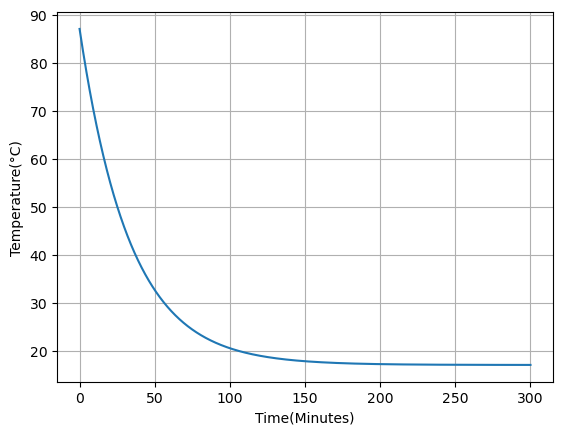

3. Suppose that the initial temperature of a cup of coffee is 87C, but the coffee can be sipped comfortably only when its temperature is ≤ 75C. Assume that the addition of cream cools the coffee by 5C. If you are in a hurry and want to wait the shortest possible time, should the cream be added first and the coffee be allowed to cool, or should you wait until the coffee has cooled to 80C before adding the cream? Use your program to simulate these two cases.

Based on the simulation, you would want to put the creamer in right after letting it cool to 80°C.

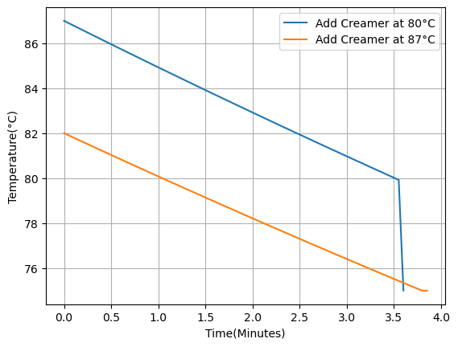